# Applied Multivariate: Latent class analysis

### Avoiding local maxima

A well-known drawback of the EM algorithm is that depending upon the initial parameter values chosen in the first iteration, the algorithm may only find a local, rather than the global, maximum of the log-likelihood function

If this does happen, you can reorder your class “names”

```r
nes.basic2 <- poLCA(f.1, election, nclass = 3, verbose = TRUE, nrep = 10)
```

```
Model 1: llik = -16714.66 ... best llik = -16714.66
Model 2: llik = -16714.66 ... best llik = -16714.66
Model 3: llik = -16714.66 ... best llik = -16714.66
Model 4: llik = -16714.66 ... best llik = -16714.66
Model 5: llik = -16714.66 ... best llik = -16714.66
Model 6: llik = -16714.66 ... best llik = -16714.66
Model 7: llik = -16714.66 ... best llik = -16714.66
Model 8: llik = -16714.66 ... best llik = -16714.66
Model 9: llik = -16714.66 ... best llik = -16714.66
Model 10: llik = -16714.66 ... best llik = -16714.66
Conditional item response (column) probabilities,
 by outcome variable, for each class (row)

$MORALG
          1 Extremely well 2 Quite well 3 Not too well 4 Not well at all
class 1:            0.1013       0.5990         0.2552            0.0446
class 2:            0.5224       0.4109         0.0390            0.0277
class 3:            0.1851       0.3668         0.2350            0.2131

$CARESG
          1 Extremely well 2 Quite well 3 Not too well 4 Not well at all
class 1:            0.0227       0.5090         0.3819            0.0864
class 2:            0.3970       0.4605         0.0895            0.0529
class 3:            0.0879       0.2546         0.3524            0.3051

$KNOWG
          1 Extremely well 2 Quite well 3 Not too well 4 Not well at all
class 1:            0.0429       0.8058         0.1408            0.0105
class 2:            0.5878       0.3543         0.0266            0.0312
class 3:            0.2542       0.4253         0.2382            0.0822

$LEADG
          1 Extremely well 2 Quite well 3 Not too well 4 Not well at all
class 1:            0.0207       0.4886         0.4268            0.0639
class 2:            0.3747       0.4772         0.1085            0.0396
class 3:            0.0747       0.2582         0.3856            0.2816

$DISHONG
          1 Extremely well 2 Quite well 3 Not too well 4 Not well at all
class 1:            0.0519       0.2182         0.4998            0.2301
```

[output cut: 48 more lines]

```
Predicted class memberships (by modal posterior prob.)
 0.4256 0.3166 0.2578

=========================================================
Fit for 3 latent classes:
=========================================================
number of observations: 1311
number of estimated parameters: 110
residual degrees of freedom: 1201
maximum log-likelihood: -16714.66

AIC(3): 33649.32
BIC(3): 34218.96
G^2(3): 15016.7 (Likelihood ratio/deviance statistic)
X^2(3): 16748689794 (Chi-square goodness of fit)
```

```r
probs.start <- nes.basic2$probs.start
new.probs.start <- poLCA.reorder(probs.start, c(2, 3, 1))
nes.basic3 <- poLCA(f.1, election, nclass = 3, probs.start = new.probs.start)
```

```
Conditional item response (column) probabilities,
 by outcome variable, for each class (row)

$MORALG
          1 Extremely well 2 Quite well 3 Not too well 4 Not well at all
class 1:            0.5224       0.4109         0.0390            0.0277
class 2:            0.1851       0.3668         0.2350            0.2131
class 3:            0.1013       0.5990         0.2552            0.0446

$CARESG
          1 Extremely well 2 Quite well 3 Not too well 4 Not well at all
class 1:            0.3970       0.4605         0.0895            0.0529
class 2:            0.0879       0.2546         0.3524            0.3051
class 3:            0.0227       0.5090         0.3819            0.0864

$KNOWG
          1 Extremely well 2 Quite well 3 Not too well 4 Not well at all
class 1:            0.5878       0.3543         0.0266            0.0312
class 2:            0.2542       0.4253         0.2382            0.0822
class 3:            0.0429       0.8058         0.1408            0.0105

$LEADG
          1 Extremely well 2 Quite well 3 Not too well 4 Not well at all
class 1:            0.3747       0.4772         0.1085            0.0396
class 2:            0.0747       0.2582         0.3856            0.2816
class 3:            0.0207       0.4886         0.4268            0.0639

$DISHONG
          1 Extremely well 2 Quite well 3 Not too well 4 Not well at all
class 1:            0.0426       0.0487         0.3371            0.5717
class 2:            0.2007       0.3060         0.2774            0.2158
class 3:            0.0519       0.2182         0.4998            0.2301

$INTELG
          1 Extremely well 2 Quite well 3 Not too well 4 Not well at all
class 1:            0.5763       0.3698         0.0197            0.0341
class 2:            0.2936       0.4407         0.1852            0.0805
class 3:            0.0600       0.7953         0.1317            0.0130

$MORALB
```

[output cut: 38 more lines]

```
Predicted class memberships (by modal posterior prob.)
 0.3166 0.2578 0.4256

=========================================================
Fit for 3 latent classes:
=========================================================
number of observations: 1311
number of estimated parameters: 110
residual degrees of freedom: 1201
maximum log-likelihood: -16714.66

AIC(3): 33649.32
BIC(3): 34218.96
G^2(3): 15016.7 (Likelihood ratio/deviance statistic)
X^2(3): 16748689794 (Chi-square goodness of fit)
```

## Latent class regression specification

The latent class regression model further enables the researcher to estimate the effects of covariates on predicting latent class membership. Covariates are included in the latent class regression model through their effects on the priors . In the basic latent class model, it is assumed that every individual has the same prior probabilities of latent class membership. The latent class regression model, in contrast, allows individuals’ priors to vary depending upon their observed covariates.

We might expect that the way that respondents rate the presidents characteristics will depend on party affiliation. That is democratic supporters will likely be more favorable to Gore and republican supporters will likely be more favorable to Bust.

In this data set, `PARTY` is coded across seven categories, from strong Democrat at 1 to strong Republican at 7. People who primarily consider themselves Independents are at 3-4-5 on the scale.

```r
table(election$PARTY)
```

```
  1   2   3   4   5   6   7
344 272 266 201 230 212 235
```

```r
# latent class regression specification
f.party <- cbind(MORALG, CARESG, KNOWG, LEADG, DISHONG, INTELG, MORALB, CARESB, KNOWB, LEADB, DISHONB, INTELB) ~ PARTY
nes.party <- poLCA(f.party, election, nclass = 3, verbose = FALSE)
nes.party
```

```
Conditional item response (column) probabilities,
 by outcome variable, for each class (row)

$MORALG
          1 Extremely well 2 Quite well 3 Not too well 4 Not well at all
class 1:            0.6221       0.3350         0.0172            0.0258
class 2:            0.1081       0.3832         0.3038            0.2048
class 3:            0.1373       0.6682         0.1802            0.0143

$CARESG
          1 Extremely well 2 Quite well 3 Not too well 4 Not well at all
class 1:            0.4858       0.4164         0.0534            0.0444
class 2:            0.0356       0.2281         0.4501            0.2861
class 3:            0.0388       0.6138         0.2886            0.0589

$KNOWG
          1 Extremely well 2 Quite well 3 Not too well 4 Not well at all
class 1:            0.7189       0.2451         0.0040             0.032
class 2:            0.1436       0.5327         0.2556             0.068
class 3:            0.0712       0.8173         0.1025             0.009

$LEADG
          1 Extremely well 2 Quite well 3 Not too well 4 Not well at all
class 1:            0.4720       0.4326         0.0643            0.0311
class 2:            0.0278       0.1899         0.5137            0.2685
class 3:            0.0256       0.6280         0.3144            0.0320

$DISHONG
          1 Extremely well 2 Quite well 3 Not too well 4 Not well at all
class 1:            0.0518       0.0538         0.2890            0.6054
class 2:            0.1876       0.3435         0.3078            0.1611
class 3:            0.0210       0.1412         0.5341            0.3037

$INTELG
          1 Extremely well 2 Quite well 3 Not too well 4 Not well at all
class 1:            0.7381       0.2219         0.0089            0.0311
class 2:            0.1704       0.5597         0.2000            0.0698
class 3:            0.0698       0.8159         0.1003            0.0140

$MORALB
```

[output cut: 49 more lines]

```
3 / 1
            Coefficient  Std. error  t value  Pr(>|t|)
(Intercept)    -1.16155     0.17989   -6.457         0
PARTY           0.57436     0.06401    8.973         0
=========================================================
number of observations: 1300
number of estimated parameters: 112
residual degrees of freedom: 1188
maximum log-likelihood: -16222.32

AIC(3): 32668.65
BIC(3): 33247.7
X^2(3): 34565224272 (Chi-square goodness of fit)

ALERT: estimation algorithm automatically restarted with new initial values
```

```r
# Size of each latent class
nes.party$P
```

```
[1] 0.2736020 0.3405146 0.3858834
```

### Model coefficients and predictions

```r
nes.party$coeff
```

```
                 [,1]      [,2]
(Intercept) -4.979673 -1.161546
PARTY        1.367624  0.574359
```

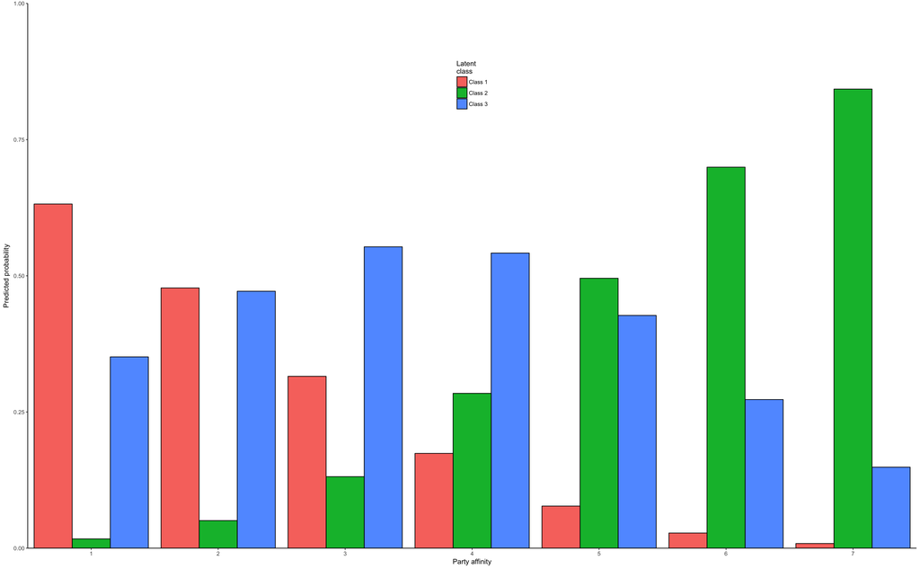

```r
pidmat <- cbind(1, c(1:7))
exb <- exp(pidmat %*% nes.party$coeff)
party_pred.num<-data.frame(party = 1:7, pred_prob = (cbind(1, exb)/(1 + rowSums(exb))))
party_pred.num %>%
  gather(class, value, - party) %>%
  mutate(class = case_when(class == "pred_prob.1" ~ "Class 1",
                           class == "pred_prob.2" ~ "Class 2",
                           class == "pred_prob.3" ~ "Class 3")) -> party_long
ggplot(data = party_long) +
  geom_col(aes(x = as.character(party), y = value, fill = class), position = "dodge", colour = "black") +
  labs(y = "Predicted probability", x = "Party affinity", fill = "Latent\nclass") +
  theme_classic() +
  coord_cartesian(ylim = c(0,1), xlim = c(0.5,7.5), expand = FALSE) +
  theme(legend.position = c(0.5, 0.85))
```

### How many classes is correct?

```r
set.seed(12348)
classes <- 6
# apply(election.rev,c(2), function(x) any(is.na(x)))
# election.rev<-na.omit(election[c(1:12,17)])
fit.stor <- data.frame(matrix(NA, classes-1,4))
names(fit.stor) <- c("classes", "llik", "aic", "bic")
for(i in 2:classes){
  print(i)
  foo<-poLCA(f.party, election, nclass = i,nrep = 5,verbose = FALSE)
  fit.stor$classes[i - 1] <- i
  fit.stor$llik[i - 1] <- foo$llik
  fit.stor$aic[i - 1] <- foo$aic
  fit.stor$bic[i - 1] <- foo$bic
  # fit.stor$E[i - 1] <- poLCA.entropy(foo)

}
```

```
[1] 2
[1] 3
[1] 4
[1] 5
[1] 6
```

```r
fit.stor<-fit.stor[order(fit.stor$bic),]
fit.stor$delta_bic <- fit.stor$bic- fit.stor$bic[1]
fit.stor
```

|  | classes | llik | aic | bic | delta_bic |
| --- | --- | --- | --- | --- | --- |
| 4 | 5 | -15540.82 | 31457.63 | 32429.62 | 0.0000 |
| 3 | 4 | -15866.70 | 32033.40 | 32808.92 | 379.3038 |
| 2 | 3 | -16222.32 | 32668.65 | 33247.70 | 818.0828 |
| 1 | 2 | -16856.21 | 33860.41 | 34243.00 | 1813.3820 |
| 5 | 6 | -17209.33 | 34870.65 | 36039.10 | 3609.4842 |

### Best model

```r
f.party <- cbind(MORALG, CARESG, KNOWG, LEADG, DISHONG, INTELG, MORALB, CARESB, KNOWB, LEADB, DISHONB, INTELB) ~ PARTY
out_party<-poLCA(f.party, election, nclass = 5,nrep = 10, na.rm = TRUE,verbose = TRUE)
```

```
Model 1: llik = -16576.72 ... best llik = -16576.72
Model 2: llik = -16864.16 ... best llik = -16576.72
Model 3: llik = -15541.5 ... best llik = -15541.5
Model 4: llik = -17519.25 ... best llik = -15541.5
Model 5: llik = -15859.37 ... best llik = -15541.5
Model 6: llik = -15639.48 ... best llik = -15541.5
Model 7: llik = -15540.82 ... best llik = -15540.82
Model 8: llik = -15540.82 ... best llik = -15540.82
Model 9: llik = -15540.82 ... best llik = -15540.82
Model 10: llik = -15540.96 ... best llik = -15540.82
Conditional item response (column) probabilities,
 by outcome variable, for each class (row)

$MORALG
          1 Extremely well 2 Quite well 3 Not too well 4 Not well at all
class 1:            0.1411       0.6068         0.1869            0.0652
class 2:            0.7209       0.2687         0.0042            0.0062
class 3:            0.2304       0.6930         0.0732            0.0034
class 4:            0.0107       0.3496         0.4350            0.2047
class 5:            0.2086       0.4191         0.2112            0.1611

$CARESG
          1 Extremely well 2 Quite well 3 Not too well 4 Not well at all
class 1:            0.0690       0.5343         0.2380            0.1587
class 2:            0.6031       0.3398         0.0469            0.0102
class 3:            0.0635       0.7476         0.1740            0.0149
class 4:            0.0102       0.1401         0.5970            0.2527
class 5:            0.0802       0.2754         0.3591            0.2853

$KNOWG
          1 Extremely well 2 Quite well 3 Not too well 4 Not well at all
class 1:            0.1240       0.6676         0.1341            0.0743
class 2:            0.8421       0.1547         0.0000            0.0032
class 3:            0.1436       0.8243         0.0321            0.0000
class 4:            0.0197       0.6137         0.3229            0.0438
class 5:            0.2932       0.4518         0.1757            0.0793

$LEADG
          1 Extremely well 2 Quite well 3 Not too well 4 Not well at all
class 1:            0.0258       0.5711         0.3114            0.0917
```

[output cut: 93 more lines]

```
5 / 1
            Coefficient  Std. error  t value  Pr(>|t|)
(Intercept)    -3.96926     0.39941   -9.938         0
PARTY           0.91716     0.08776   10.450         0
=========================================================
number of observations: 1300
number of estimated parameters: 188
residual degrees of freedom: 1112
maximum log-likelihood: -15540.82

AIC(5): 31457.63
BIC(5): 32429.62
X^2(5): 250960718 (Chi-square goodness of fit)

ALERT: estimation algorithm automatically restarted with new initial values
```

```r
out_party
```

```
Conditional item response (column) probabilities,
 by outcome variable, for each class (row)

$MORALG
          1 Extremely well 2 Quite well 3 Not too well 4 Not well at all
class 1:            0.1411       0.6068         0.1869            0.0652
class 2:            0.7209       0.2687         0.0042            0.0062
class 3:            0.2304       0.6930         0.0732            0.0034
class 4:            0.0107       0.3496         0.4350            0.2047
class 5:            0.2086       0.4191         0.2112            0.1611

$CARESG
          1 Extremely well 2 Quite well 3 Not too well 4 Not well at all
class 1:            0.0690       0.5343         0.2380            0.1587
class 2:            0.6031       0.3398         0.0469            0.0102
class 3:            0.0635       0.7476         0.1740            0.0149
class 4:            0.0102       0.1401         0.5970            0.2527
class 5:            0.0802       0.2754         0.3591            0.2853

$KNOWG
          1 Extremely well 2 Quite well 3 Not too well 4 Not well at all
class 1:            0.1240       0.6676         0.1341            0.0743
class 2:            0.8421       0.1547         0.0000            0.0032
class 3:            0.1436       0.8243         0.0321            0.0000
class 4:            0.0197       0.6137         0.3229            0.0438
class 5:            0.2932       0.4518         0.1757            0.0793

$LEADG
          1 Extremely well 2 Quite well 3 Not too well 4 Not well at all
class 1:            0.0258       0.5711         0.3114            0.0917
class 2:            0.5918       0.3656         0.0346            0.0080
class 3:            0.0611       0.7357         0.1961            0.0071
class 4:            0.0108       0.0743         0.6774            0.2376
class 5:            0.0714       0.2916         0.3695            0.2675

$DISHONG
          1 Extremely well 2 Quite well 3 Not too well 4 Not well at all
class 1:            0.0586       0.1144         0.4771            0.3498
class 2:            0.0556       0.0363         0.2412            0.6669
class 3:            0.0010       0.1222         0.5258            0.3511
```

[output cut: 83 more lines]

```
5 / 1
            Coefficient  Std. error  t value  Pr(>|t|)
(Intercept)    -3.96926     0.39941   -9.938         0
PARTY           0.91716     0.08776   10.450         0
=========================================================
number of observations: 1300
number of estimated parameters: 188
residual degrees of freedom: 1112
maximum log-likelihood: -15540.82

AIC(5): 31457.63
BIC(5): 32429.62
X^2(5): 250960718 (Chi-square goodness of fit)

ALERT: estimation algorithm automatically restarted with new initial values
```

```r
out_party$coeff
```

```
                 [,1]       [,2]       [,3]       [,4]
(Intercept)  1.413213 -0.1551836 -3.7730131 -3.9692562
PARTY       -0.580492  0.1889329  0.9287816  0.9171584
```

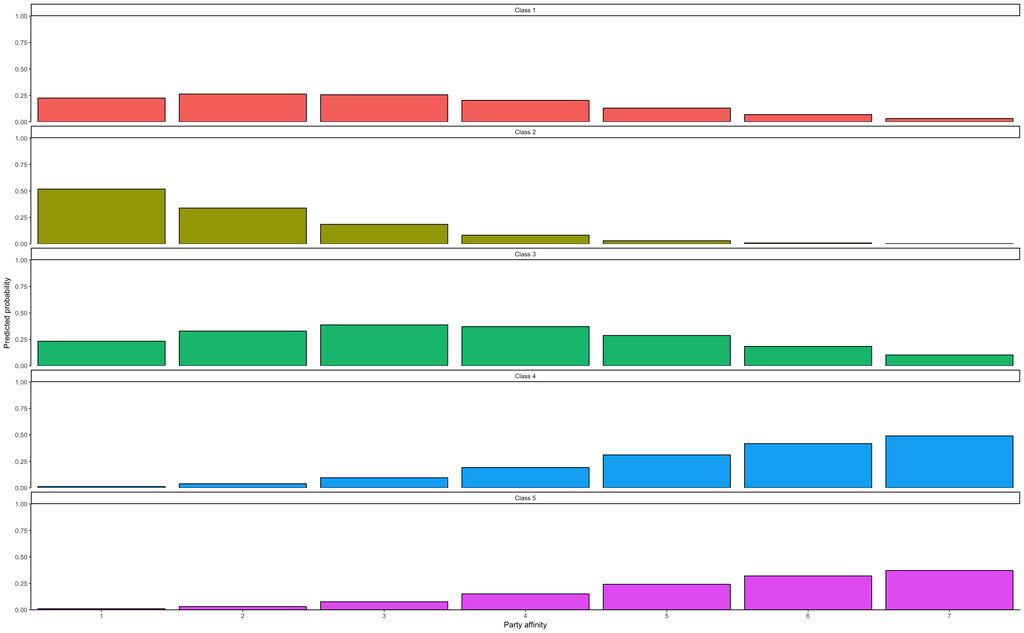

```r
pidmat <- cbind(1, c(1:7))
exb <- exp(pidmat %*% out_party$coeff)
party_pred.num2<-data.frame(party = 1:7, pred_prob = (cbind(1, exb)/(1 + rowSums(exb))))
party_pred.num2 %>%
  gather(class, value, - party) %>%
  mutate(class = case_when(class == "pred_prob.1" ~ "Class 1",
                           class == "pred_prob.2" ~ "Class 2",
                           class == "pred_prob.3" ~ "Class 3",
                           class == "pred_prob.4" ~ "Class 4",
                           class == "pred_prob.5" ~ "Class 5")) -> party2_long
ggplot(data = party2_long) +
  geom_col(aes(x = as.character(party), y = value, fill = class), position = "dodge", colour = "black") +
  labs(y = "Predicted probability", x = "Party affinity", fill = "Latent\nclass") +
  theme_classic() +
  coord_cartesian(ylim = c(0,1), xlim = c(0.5,7.5), expand = FALSE) +
  facet_wrap(~class, ncol = 1) +
  theme(legend.position ="none")
```

## Bayesian Approach

We will use the `BayesLCA` package to explore LCAs using the Bayesian approach. The data we will use is the `Alzheimer` data set. This includes the presence or absence of 6 symptoms of Alzheimer’s disease (AD) in 240 patients diagnosed with early onset AD conducted in the Mercer Institute in St. James’s Hospital, Dublin.

```r
data("Alzheimer")
head(Alzheimer)
```

|  | Hallucination | Activity | Aggression | Agitation | Diurnal | Affective |
| --- | --- | --- | --- | --- | --- | --- |
| 1 | 0 | 0 | 0 | 0 | 0 | 0 |
| 2 | 0 | 0 | 0 | 0 | 0 | 0 |
| 3 | 0 | 0 | 0 | 0 | 0 | 0 |
| 4 | 0 | 0 | 0 | 0 | 0 | 0 |
| 5 | 0 | 0 | 0 | 0 | 0 | 0 |
| 6 | 0 | 0 | 0 | 0 | 0 | 0 |

```r
names(Alzheimer)
```

```
[1] "Hallucination" "Activity"      "Aggression"    "Agitation"     "Diurnal"       "Affective"
```

```r
# "Hallucination","Activity","Aggression" ,"Agitation","Diurnal","Affective"
Alzheimer %>%
  unite(combo, Hallucination:Affective, sep = "") %>%
  group_by(combo) %>%
  summarize(N = n()) %>%
  arrange(desc(N))
```

| combo | N |
| --- | --- |
| 010001 | 35 |
| 000001 | 25 |
| 010101 | 24 |
| 010000 | 20 |
| 000000 | 18 |
| 011101 | 14 |
| 010011 | 11 |
| 010111 | 11 |
| 000101 | 9 |
| 011001 | 9 |

[output cut: 29 more lines]

Lets start to find some classes. First convert the data into the appropriate data set up.

```r
alz <- data.blca(Alzheimer)
alz
```

```
$counts.n
000000 000001 000010 000011 000100 000101 000110 000111 001000 001001 001010 001011 001101 001111 010000 010001 010010 010011 010100
    18     25      1      6      3      9      1      3      2      4      1      1      2      3     20     35      2     11      3
010101 010111 011000 011001 011010 011011 011101 011110 011111 100000 100001 100101 101001 110000 110001 110011 110101 111001 111011
    24     11      1      9      3      2     14      1      6      1      1      1      1      2      5      2      1      1      1
111111
     3

$data
      Hallucination Activity Aggression Agitation Diurnal Affective
 [1,]             0        0          0         0       0         0
 [2,]             0        0          0         0       0         1
 [3,]             0        0          0         0       1         0
 [4,]             0        0          0         0       1         1
 [5,]             0        0          0         1       0         0
```

[output cut: 37 more lines]

```r
alz.3.em <- blca.em(alz, 3, restarts = 20, sd = TRUE)
```

```
Restart number 1, logpost = -744.28...
Restart number 2, logpost = -744.29...
New maximum found... Restart number 3, logpost = -742.79...
Restart number 4, logpost = -744.28...
New maximum found... Restart number 5, logpost = -742.79...
Restart number 6, logpost = -745.03...
Restart number 7, logpost = -744.28...
Restart number 8, logpost = -744.28...
Restart number 9, logpost = -742.8...
Restart number 10, logpost = -745.03...
Restart number 11, logpost = -744.28...
Restart number 12, logpost = -745.23...
Restart number 13, logpost = -744.28...
Restart number 14, logpost = -742.8...
Restart number 15, logpost = -745.03...
Restart number 16, logpost = -745.03...
Restart number 17, logpost = -742.8...
Restart number 18, logpost = -747.58...
Restart number 19, logpost = -745.03...
Restart number 20, logpost = -747.58...
```

```
some point estimates located at boundary (i.e., are 1 or 0). posterior standard deviations will be 0 for these values.
```

```r
alz.3.em
```

```
MAP Estimates:


Item Probabilities:

        Hallucination Activity Aggression Agitation Diurnal Affective
Group 1         0.062    0.518      0.063     0.132   0.096     0.549
Group 2         0.100    0.790      0.372     0.594   0.364     1.000
Group 3         0.000    0.821      0.998     0.208   1.000     0.000

Membership Probabilities:

Group 1 Group 2 Group 3
  0.502   0.479   0.020

Posterior Standard Deviation Estimates:


Item Probabilities:

        Hallucination Activity Aggression Agitation Diurnal Affective
Group 1         0.029    0.058      0.033     0.044   0.057     0.084
Group 2         0.033    0.055      0.066     0.085   0.057     0.000
Group 3         0.000    0.198      0.579     0.193   0.000     0.000

Membership Probabilities:

Group 1 Group 2 Group 3
  0.094   0.090   0.014
```

```r
alz3.boot <- blca.boot(alz, fit = alz.3.em, B = 1000, relabel = TRUE)
```

[output not shown]

[output cut: 87 more lines]

```r
names(alz3.boot)
```

```
 [1] "call"              "itemprob"          "classprob"         "Z"                 "itemprob.se"       "itemprob.sd"
 [7] "classprob.se"      "classprob.sd"      "classprob.initial" "itemprob.initial"  "samples"           "logpost"
[13] "BIC"               "AIC"               "label"             "counts"            "prior"
```

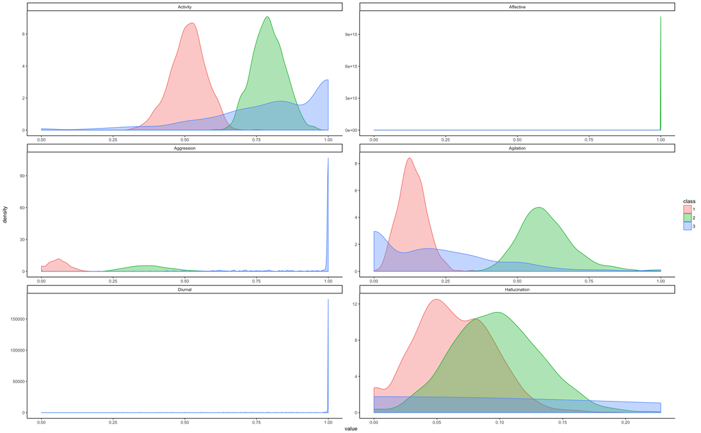

```r
as.tibble(alz3.boot$samples$itemprob) %>%
  gather(all, value) %>%
  separate(all, c("class","symptom"), "[.]")  -> prob_data_for_plot


  ggplot(prob_data_for_plot,aes(value,fill = class, colour = class)) +
    geom_density(alpha = 0.35) +
    facet_wrap(~symptom, scales = "free", ncol = 2)  +
    theme_classic()
```

Note the spikes in the plots for the Affective, Diurnal and Aggression symptoms. This indicates that the parameter estimates in question remained unchanged over all bootstrap samples.